# Mapping the Landscape of Precision Public Health: A Bibliometric Analysis of Influential Works and Key Contributors

- Show All Code
- Hide All Code
- View Source

Authors

Affiliation

Mohd Azmi Bin Suliman

Institut Kesihatan Umum

Tham Sin Wan

Institut Kesihatan Umum

Published

Saturday, 20/04/2024

# Setup

## Library & Setup

```r
pacman::p_load(tidyverse, bibliometrix, stringi,
               kableExtra, summarytools)

bibds_wos_por <- read_csv("240419_bibds_wos_postor.csv")
```

# Introduction

- Precision public health is a relatively new concept.
- Precision public health was coined following the trend of precision medicine.
- In precision medicine, treatment is tailored to individual patient, by utilising the advancement of genomic sequencing and molecular biology.
- Meanwhile, in precision public health, interventions are tailored to individual or group, by using data and technology.
- In this study, we want to map the landscape of precision public health, by identifying influential works and key contributors.

# Methodology

## Data Source & Inclusion Criteria

- Database: Web of Science Core Collection, which include
  - A&HCI: Arts & Humanities Citation Index
  - ESCI: Emerging Sources Citation Index
  - SCI-EXPANDED: Science Citation Index Expanded
  - SSCI: Social Sciences Citation Index
- Date Access: 19/04/2024
- Search Term: TS=(“public health precision”) OR TS=(“precision public health”)
  - TS: Topic, which include Title, Abstract and Author’s Keywords
  - TI: Title
  - link: https://www.webofscience.com/wos/woscc/summary/4e07b2e9-e0db-4bff-ac3d-f09a49adaed7-e0a53927/relevance/1

## Data Analysis

- Software
  - R
  - RStudio
  - Bibliometrix
- Parameters
  - Production by Year
  - Influential Articles
  - Influential Authors
  - Influential Journals
  - Influential Keywords

# Results

## Production by Year

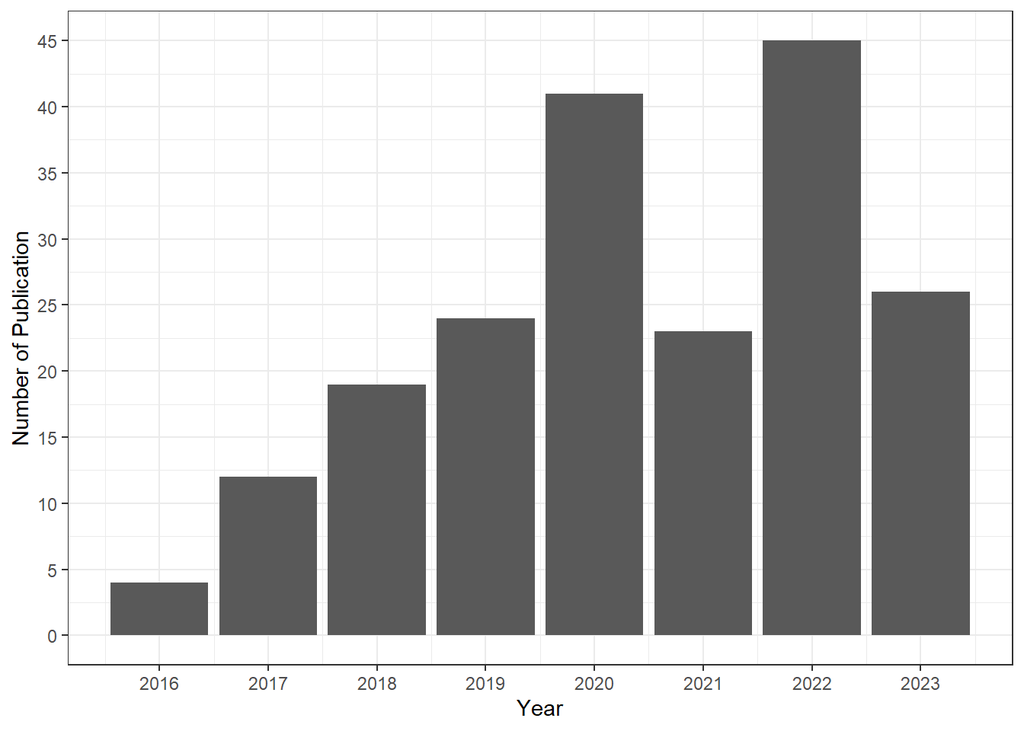

```r
bibds_wos_por %>%
  count(PY) %>%
  ggplot(aes(x = PY, y = n)) +
  geom_col() +
  scale_x_continuous(breaks = seq(2000, 2030, 1),
                     name = "Year") +
  scale_y_continuous(breaks = seq(0, 50, 5),
                     name = "Number of Publication") +
  theme_bw()
```

## Influential Articles

### Total Cited

```r
bibds_wos_por %>%
  select(TI, AU, TC, DI) %>%
  arrange(desc(TC)) %>%
  mutate(Rank = row_number(), .before = 1) %>%
  filter(Rank < 11)
```

| Rank | TI | AU | TC | DI |
| --- | --- | --- | --- | --- |
| 1 | PRECISION PUBLIC HEALTH FOR THE ERA OF PRECISION MEDICINE | KHOURY MJ;IADEMARCO MF;RILEY WT | 326 | 10.1016/j.amepre.2015.08.031 |
| 2 | MAPPING UNDER-5 AND NEONATAL MORTALITY IN AFRICA, 2000-15: A BASELINE ANALYSIS FOR THE SUSTAINABLE DEVELOPMENT GOALS | GOLDING N;BURSTEIN R;LONGBOTTOM J;BROWNE AJ;FULLMAN N;OSGOOD-ZIMMERMAN A;EARL S;CAMERON E;CASEY DC;DWYER-LINDGREN L;FARAG TH;FLAXMAN AD;FRASER MS;GETHING PW;GIBSON HS;GRAETZ LK;KULIKOFF XR;LIM B;MOROZ… | 175 | 10.1016/S0140-6736(17)31758-0 |
| 3 | MAPPING CHILD GROWTH FAILURE IN AFRICA BETWEEN 2000 AND 2015 | OSGOOD-ZIMMERMAN A;MILLEAR AI;STUBBS RW;SHIELDS C;PICKERING BV;EARL L;GRAETZ N;KINYOKI DK;RAY SE;BHATT AJ;BURSTEIN R;CAMERON E;CASEY DC;DESHPANDE A;FULLMAN N;GETHING HS;HENRY NJ;HERRERO M;KRAUSE LK;LE… | 150 | 10.1038/nature25760 |
| 4 | PATHOGEN GENOMICS IN PUBLIC HEALTH | ARMSTRONG GL;MACCANNELL DR;TAYLOR HA;NEUHAUS EB;BRADBURY RS;POSEY JE;GWINN M | 113 | 10.1056/NEJMsr1813907 |
| 5 | DIGITAL TWINS: FROM PERSONALISED MEDICINE TO PRECISION PUBLIC HEALTH | BOULOS MNK;ZHANG P | 109 | 10.3390/jpm11080745 |
| 6 | BIG DATA’S ROLE IN PRECISION PUBLIC HEALTH | DOLLEY S | 105 | 10.3389/fpubh.2018.00068 |
| 7 | FROM PUBLIC HEALTH GENOMICS TO PRECISION PUBLIC HEALTH: A 20-YEAR JOURNEY | KHOURY MJ;BOWEN MS;CLYNE M;DOTSON WD;GWINN ML;GREEN RF;KOLOR K;RODRIGUEZ JL;WULF A;YU W | 99 | 10.1038/gim.2017.211 |
| 8 | CONTAINING COVID-19 AMONG 627,386 PERSONS IN CONTACT WITH THE DIAMOND PRINCESS CRUISE SHIP PASSENGERS WHO DISEMBARKED IN TAIWAN: BIG DATA ANALYTICS | CHEN CM;JYAN HW;CHIEN SC;JEN HH;HSU CY;LEE PC;LEE YT;CHEN MY;CHEN LS;CHEN HH;CHAN CC | 93 | 10.2196/19540 |
| 9 | BIG DATA HURDLES IN PRECISION MEDICINE AND PRECISION PUBLIC HEALTH | PROSPERI M;MIN JS;BIAN J;MODAVE F | 88 | 10.1186/s12911-018-0719-2 |
| 10 | MAPPING GEOGRAPHICAL INEQUALITIES IN ACCESS TO DRINKING WATER AND SANITATION FACILITIES IN LOW-INCOME AND MIDDLE-INCOME COUNTRIES, 2000-17 | DESHPANDE A;MILLER-PETRIE MK;LINDSTEDT PA;BAUMANN MM;JOHNSON KB;BLACKER BF;ABBASTABAR H;ABD-ALLAH F;ABDELALIM I;ABEGAZ KH;ABEJIE AN;ABREU LG;ABRIGO A;ACCROMBESSI MMK;ADAMU AA;ADEBAYO OM;ADEDEJI IA;ADE… | 78 | NA |

### Total Cited per Year

```r
bibds_wos_por %>%
  select(TI, AU, DI, PY, TC) %>%
  mutate(dur = 2024 - PY + 1,
         tcy = TC / dur) %>%
  arrange(desc(tcy)) %>%
  mutate(Rank = row_number(), .before = 1) %>%
  filter(Rank < 11)
```

| Rank | TI | AU | DI | PY | TC | dur | tcy |
| --- | --- | --- | --- | --- | --- | --- | --- |
| 1 | PRECISION PUBLIC HEALTH FOR THE ERA OF PRECISION MEDICINE | KHOURY MJ;IADEMARCO MF;RILEY WT | 10.1016/j.amepre.2015.08.031 | 2016 | 326 | 9 | 36.22222 |
| 2 | DIGITAL TWINS: FROM PERSONALISED MEDICINE TO PRECISION PUBLIC HEALTH | BOULOS MNK;ZHANG P | 10.3390/jpm11080745 | 2021 | 109 | 4 | 27.25000 |
| 3 | MAPPING UNDER-5 AND NEONATAL MORTALITY IN AFRICA, 2000-15: A BASELINE ANALYSIS FOR THE SUSTAINABLE DEVELOPMENT GOALS | GOLDING N;BURSTEIN R;LONGBOTTOM J;BROWNE AJ;FULLMAN N;OSGOOD-ZIMMERMAN A;EARL S;CAMERON E;CASEY DC;DWYER-LINDGREN L;FARAG TH;FLAXMAN AD;FRASER MS;GETHING PW;GIBSON HS;GRAETZ LK;KULIKOFF XR;LIM B;MOROZ… | 10.1016/S0140-6736(17)31758-0 | 2017 | 175 | 8 | 21.87500 |
| 4 | MAPPING CHILD GROWTH FAILURE IN AFRICA BETWEEN 2000 AND 2015 | OSGOOD-ZIMMERMAN A;MILLEAR AI;STUBBS RW;SHIELDS C;PICKERING BV;EARL L;GRAETZ N;KINYOKI DK;RAY SE;BHATT AJ;BURSTEIN R;CAMERON E;CASEY DC;DESHPANDE A;FULLMAN N;GETHING HS;HENRY NJ;HERRERO M;KRAUSE LK;LE… | 10.1038/nature25760 | 2018 | 150 | 7 | 21.42857 |
| 5 | PATHOGEN GENOMICS IN PUBLIC HEALTH | ARMSTRONG GL;MACCANNELL DR;TAYLOR HA;NEUHAUS EB;BRADBURY RS;POSEY JE;GWINN M | 10.1056/NEJMsr1813907 | 2019 | 113 | 6 | 18.83333 |
| 6 | CONTAINING COVID-19 AMONG 627,386 PERSONS IN CONTACT WITH THE DIAMOND PRINCESS CRUISE SHIP PASSENGERS WHO DISEMBARKED IN TAIWAN: BIG DATA ANALYTICS | CHEN CM;JYAN HW;CHIEN SC;JEN HH;HSU CY;LEE PC;LEE YT;CHEN MY;CHEN LS;CHEN HH;CHAN CC | 10.2196/19540 | 2020 | 93 | 5 | 18.60000 |
| 7 | MAPPING GEOGRAPHICAL INEQUALITIES IN ACCESS TO DRINKING WATER AND SANITATION FACILITIES IN LOW-INCOME AND MIDDLE-INCOME COUNTRIES, 2000-17 | DESHPANDE A;MILLER-PETRIE MK;LINDSTEDT PA;BAUMANN MM;JOHNSON KB;BLACKER BF;ABBASTABAR H;ABD-ALLAH F;ABDELALIM I;ABEGAZ KH;ABEJIE AN;ABREU LG;ABRIGO A;ACCROMBESSI MMK;ADAMU AA;ADEBAYO OM;ADEDEJI IA;ADE… | NA | 2020 | 78 | 5 | 15.60000 |
| 8 | BIG DATA’S ROLE IN PRECISION PUBLIC HEALTH | DOLLEY S | 10.3389/fpubh.2018.00068 | 2018 | 105 | 7 | 15.00000 |
| 9 | FROM PUBLIC HEALTH GENOMICS TO PRECISION PUBLIC HEALTH: A 20-YEAR JOURNEY | KHOURY MJ;BOWEN MS;CLYNE M;DOTSON WD;GWINN ML;GREEN RF;KOLOR K;RODRIGUEZ JL;WULF A;YU W | 10.1038/gim.2017.211 | 2018 | 99 | 7 | 14.14286 |
| 10 | BIG DATA HURDLES IN PRECISION MEDICINE AND PRECISION PUBLIC HEALTH | PROSPERI M;MIN JS;BIAN J;MODAVE F | 10.1186/s12911-018-0719-2 | 2018 | 88 | 7 | 12.57143 |

## Influential Authors

```r
bibds_wos_por %>%
  select(AU) %>%
  separate_longer_delim(AU, ";") %>%
  count(AU) %>%
  arrange(desc(n), AU) %>%
  filter(n > 4) %>%
  mutate(Rank = row_number(), .before = 1)
```

| Rank | AU | n |
| --- | --- | --- |
| 1 | LAUSCHKE VM | 8 |
| 2 | BAYNAM G | 7 |
| 3 | ALLEN CG | 6 |
| 4 | KHOURY MJ | 6 |
| 5 | ZHOU Y | 6 |
| 6 | DAWKINS HJS | 5 |
| 7 | GOLDBLATT J | 5 |
| 8 | GUPTA R | 5 |
| 9 | HAY SI | 5 |
| 10 | MURRAY CJL | 5 |
| 11 | PACHTER N | 5 |
| 12 | WIENS KE | 5 |

## Influential Journals

### Top Journals

```r
bibds_wos_por %>%
  count(SO) %>%
  arrange(desc(n), SO) %>%
  mutate(Rank = row_number(), .before = 1) %>%
  filter(n > 2)
```

| Rank | SO | n |
| --- | --- | --- |
| 1 | FRONTIERS IN PUBLIC HEALTH | 8 |
| 2 | FRONTIERS IN GENETICS | 6 |
| 3 | INTERNATIONAL JOURNAL OF ENVIRONMENTAL RESEARCH AND PUBLIC HEALTH | 6 |
| 4 | JOURNAL OF MEDICAL INTERNET RESEARCH | 6 |
| 5 | GENETICS IN MEDICINE | 5 |
| 6 | HUMAN GENETICS | 4 |
| 7 | PLOS ONE | 4 |
| 8 | PUBLIC HEALTH GENOMICS | 4 |
| 9 | AMERICAN JOURNAL OF PREVENTIVE MEDICINE | 3 |
| 10 | BMC PUBLIC HEALTH | 3 |
| 11 | BMJ GLOBAL HEALTH | 3 |
| 12 | BMJ OPEN | 3 |
| 13 | JMIR PUBLIC HEALTH AND SURVEILLANCE | 3 |
| 14 | JOURNAL OF PERSONALIZED MEDICINE | 3 |
| 15 | JOURNAL OF PUBLIC HEALTH DENTISTRY | 3 |
| 16 | SCIENTIFIC REPORTS | 3 |

### Bradford’s Law

Bradford’s law stated that, in a given subject area, a small number of journals account for a sizeable portion of the total publications in that area, whereas increasing numbers of journals publish fewer articles in that area.

It can be group into 3 zone, with core zone is the smallest number of journals that account for the largest number of articles.

```r
bibds_wos_por %>%
  count(SO) %>%
  arrange(desc(n), SO) %>%
  mutate(sum_n = cumsum(n)) %>%
  mutate(Rank = row_number(), .before = 1) %>%
  filter(sum_n <= sum(n) / 3 + 1)
```

| Rank | SO | n | sum_n |
| --- | --- | --- | --- |
| 1 | FRONTIERS IN PUBLIC HEALTH | 8 | 8 |
| 2 | FRONTIERS IN GENETICS | 6 | 14 |
| 3 | INTERNATIONAL JOURNAL OF ENVIRONMENTAL RESEARCH AND PUBLIC HEALTH | 6 | 20 |
| 4 | JOURNAL OF MEDICAL INTERNET RESEARCH | 6 | 26 |
| 5 | GENETICS IN MEDICINE | 5 | 31 |
| 6 | HUMAN GENETICS | 4 | 35 |
| 7 | PLOS ONE | 4 | 39 |
| 8 | PUBLIC HEALTH GENOMICS | 4 | 43 |
| 9 | AMERICAN JOURNAL OF PREVENTIVE MEDICINE | 3 | 46 |
| 10 | BMC PUBLIC HEALTH | 3 | 49 |
| 11 | BMJ GLOBAL HEALTH | 3 | 52 |
| 12 | BMJ OPEN | 3 | 55 |
| 13 | JMIR PUBLIC HEALTH AND SURVEILLANCE | 3 | 58 |
| 14 | JOURNAL OF PERSONALIZED MEDICINE | 3 | 61 |
| 15 | JOURNAL OF PUBLIC HEALTH DENTISTRY | 3 | 64 |

## Influential Keywords

### Author’s Keywords

```r
bibds_wos_por %>%
  select(DE) %>%
  separate_longer_delim(DE, ";") %>%
  count(DE) %>%
  arrange(desc(n), DE) %>%
  filter(n > 6) %>%
  mutate(Rank = row_number(), .before = 1)
```

| Rank | DE | n |
| --- | --- | --- |
| 1 | PRECISION PUBLIC HEALTH | 64 |
| 2 | NA | 56 |
| 3 | PUBLIC HEALTH | 32 |
| 4 | PRECISION MEDICINE | 24 |
| 5 | GENOMICS | 17 |
| 6 | HEALTH | 14 |
| 7 | COVID-19 | 10 |
| 8 | BIG DATA | 7 |
| 9 | EPIDEMIOLOGY | 7 |
| 10 | GENETICS | 7 |

### WOS Keywords

```r
bibds_wos_por %>%
  select(ID) %>%
  separate_longer_delim(ID, ";") %>%
  count(ID) %>%
  arrange(desc(n), ID) %>%
  filter(n > 7) %>%
  mutate(Rank = row_number(), .before = 1)
```

| Rank | ID | n |
| --- | --- | --- |
| 1 | NA | 27 |
| 2 | MEDICINE | 20 |
| 3 | MORTALITY | 17 |
| 4 | DISEASE | 14 |
| 5 | HEALTH | 14 |
| 6 | CARE | 13 |
| 7 | RISK | 13 |
| 8 | ASSOCIATION | 12 |
| 9 | IMPACT | 11 |
| 10 | GENOMICS | 10 |
| 11 | AFRICA | 8 |
| 12 | INTERVENTIONS | 8 |

# Conclusion

# References

1. Ramaswami, R., Bayer, R., & Galea, S. (2018). Precision Medicine from a Public Health Perspective. Annual review of public health, 39, 153–168. https://doi.org/10.1146/annurev-publhealth-040617-014158
2. Akhoon, Neha. “Precision Medicine: A New Paradigm in Therapeutics.” International journal of preventive medicine vol. 12 12. 24 Feb. 2021, doi:10.4103/ijpvm.IJPVM_375_19
3. Aria, M., & Cuccurullo, C. (2017). bibliometrix: An R-tool for comprehensive science mapping analysis. Journal of Informetrics, 11(4), 959-975. https://doi.org/10.1016/j.joi.2017.08.007